# ILP Reserve Selection Model Tutorial

Updated 27 July 2019

### Import necessary libraries (install if needed)

```r
library(kableExtra)
library(Matrix)
library(slam)
library(sp)
library(raster)
library(glpkAPI)
library(RColorBrewer)
```

### Set working directory

Set your working directory to include domain.RData

```r
setwd("/Users/zackoyafuso/Google Drive/GitHub/ILP-Reserve_Selection_Model/")
```

### Load spatial domain

```r
load('domain.RData')
```

The raster `domain` has **48** columns and **39** rows. Of the **1872** raster cells, there are **416** cells to be included in the analysis. These cells are called planning units (PUs) and will be referenced as such hereafter.

### Data Layers

This is what the spatial domain looks like at 2 km resolution. The brown cells are the PUs and the unfilled cells are cells in the domain of the raster but not included in the analysis. The two other major data layers are the opportunity cost and species (or conservation) layers.

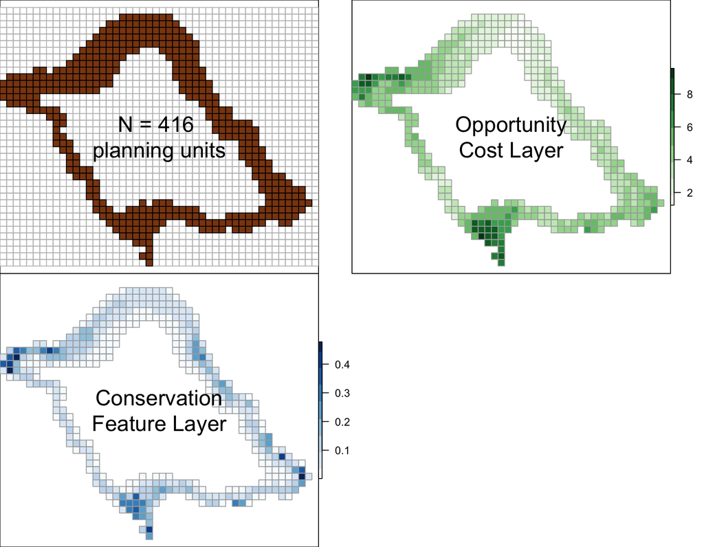

### Cell Neighbors

The compactness objective is defined as the total number of adjacent chosen PUs. This entails calculating the cardinal PU neighbors for each PU. One way to do this is to calculate whether a planning unit is a corner, edge, or inner cell on the raster domain. Depending on the type of cell, its neighbors can be correctly calculated. The cells are indexed in a horizontal reading frame. Then for each PU, we calcualte the adjacent neighboring planning units. This information is stored in a matrix called `neighbor_matrix` with 416 rows and 4 columns (for each cardinal direction).

Because most of the cells in the raster domain are not included in the analysis, we now change the indexing system to only include the cells that are planning units.

|  | W | E | N | S |
| --- | --- | --- | --- | --- |
| 1 | NA | 2 | NA | 11 |
| 2 | 1 | 3 | NA | 12 |
| 3 | 2 | 4 | NA | 13 |
| 4 | 3 | 5 | NA | 14 |
| 5 | 4 | 6 | NA | 15 |
| 6 | 5 | 7 | NA | 16 |

A preview of the data layer information is provided below:

| new_idx | old_idx | cost | spp |
| --- | --- | --- | --- |
| 1 | 67 | 2.17 | 0.023 |
| 2 | 68 | 1.97 | 0.049 |
| 3 | 69 | 2.27 | 0.062 |
| 4 | 70 | 1.90 | 0.071 |
| 5 | 71 | 2.10 | 0.078 |
| 6 | 72 | 2.33 | 0.088 |

### Objective Functions

We first define two objective functions, opportunity cost and conservation value:
$$argmin
\begin{equation}
\sum_{i=1}^{N} c_i x_i \text{ Opportunity Cost}
\end{equation}$$

$$argmax
\begin{equation}
\sum_{i=1}^{N} r_i x_i \text{ Conservation Value}
\end{equation}$$

$x_i$: binary decision variable, $1$ if $i^{th}$ PU is chosen, $0$ otherwise.

$c_i$: opportunity cost of the $i^{th}$ PU.

$r_i$: conservation value of the $i^{th}$ PU.

Total area is often as a target decided a priori. We specify this constraint using an inequality and maximum proportion of the total area of the spatial domain ($A$):

$$s.t.
\begin{equation}
\sum_{i=1}^{N} x_i \leq AN
\end{equation}$$

At this point, there are **416** decision variables. The compactness objective is an inherently non-linear relationship, as it involves the interactions of PUs. A few steps are added to linearize the compactness objective. First, we introduce a new binary decision variable, $z_{ij}$ denoting the selection of adjacent cells $i$ and $j$. There are a total of $M$ cell adjacencies in the spatial domain while $E$ comprises the set of neighboring planning units. Thus, the compactness objective is defined as:

$$argmax
\begin{equation}
\sum_{(i,j)\in E} b_{ij}
\end{equation}$$

We also need to add three constraints to make sure that if $z_{ij}$ is chosen (i.e., $z_{ij} = 1$), $x_i$ and $x_j$ are chosen as well (i.e., $x_i = x_j = 1$), and vice versa:

1. $z_{ij} - x_i \leq 0$
2. $z_{ij} - x_j \leq 0$
3. $z_{ij} - x_i -x_j \geq -1$

The constraints can be written in a linear (i.e., matrix) format, and the coefficients of the constraints can be formatted conveniently using a constraint matrix with the number of columns corresponding to the number of decision variables (N + M) and the number of rows corresponding to the number of constraints (3M + other constraints added in the model). This is generally a very large and sparse (i.e., lots of zeros) matrix. In R, sparse matrices are constructed by feeding the `Matrix::sparseMatrix()` function three vectors that correspond to the non-zero elements of the matrix:

1. `mc` is a vector of column indices;
2. `mr` is a vector of row indices;
3. `mz` is a vector of coefficients;

With the sparse matrix are two vectors for the inequalities of the constraints (`sense`) and the value of the right hand side of the inequality (`rhs`)

```r
mc = mr = mz = sense = rhs = c()
## index for the vectors of the sparse constraints matrix
idx = 1
# index for the current row (cr)
cr = 0
# index for the zth added boundary decision variable
z = n_pus

M = 0 #cumulative number of cell interactions

for (i in 1:n_pus){ #for each true pu
  #which pus are neighboring?
  ids <- neighbor_matrix[i,which(neighbor_matrix[i,]>0)]

  #To ensure we don't double count cell adjacencies
  if(all(ids < i)) next

  unique_ids = ids[ids > i]

  #add to the number of interactions
  M = M + length(unique_ids)

  for (j in 1:length(unique_ids)){ #for each of the neighbors

    #Update current row index, number of decision variables
    cr = cr + 1
    z = z + 1

    # First constraint: z_ij - x_i <= 0
    mc[idx] <- i       #ith pu
    mr[idx] <- cr
    mz[idx] <- -1      #corresponds to -x_i
    idx <- idx + 1
    mc[idx] <- z       #zth obj val (z = z-N)
    mr[idx] <- cr
    mz[idx] <- 1       #corresponds to +z_ij
    sense[cr] = "<="
    rhs[cr] = 0
    idx <- idx + 1
    cr <- cr + 1       #Next row (constraint)

    # Second Constraint: z_ij - x_j <= 0
    mc[idx] <- unique_ids[j]  #jth neighboring pu
    mr[idx] <- cr
    mz[idx] <- -1      #corresponds to -x_j
    idx <- idx + 1
    mc[idx] <- z       #zth obj val (z = z-N)
    mr[idx] <- cr
    mz[idx] <- 1       #corresponds to z_ij
    sense[cr] = "<="
    rhs[cr] = 0
    idx <- idx + 1
    cr <- cr + 1       #Next row (constraint)

    # Third Constraint: zij - xi - xj >= -1
    mc[idx] = i        #ith pu
    mr[idx] <- cr
    mz[idx] <- -1      #corresponds to -x_i
    idx <- idx + 1
    mc[idx] <- unique_ids[j]  #jth neighboring pu
    mr[idx] <- cr
    mz[idx] <- -1      #corresponds to -x_j
    idx <- idx + 1
    mc[idx] <- z       #zth obj val (z = z-N)
    mr[idx] <- cr
    mz[idx] <- 1       #corresponds to z_ij
    idx <- idx + 1

    sense[cr] = '>='   #Switch equality to >=
    rhs[cr]   = -1
  }
}
```

#### Double-Check

To double check, the constraint matrix at this point should have number of rows corresponding to thrice the number of cell-to-cell adjacencies (M)

```r
3*M == max(mr)
```

```
## [1] TRUE
```

There should be n_pus + M columns (416 planning units plus 677 adjacencies)

```r
z == n_pus + M
```

```
## [1] TRUE
```

```r
n_pus+M == max(mc)
```

```
## [1] TRUE
```

# Solving the ILP model

```r
do_glpkAPI = function(
  area_constraint = 0.3,
  species_constraint = 0.2,
  boundary_constraint = 0.2,
  gap = 0.01,
  time_limit = Inf
){
  ################################
  ## Model Setup
  ################################
  # Opportunity Cost Vector. Because the length of the decision variable
  # vector is n_pus + M, the coefficients for the objective values consist of
  # the opportunity cost for each of the PUs, concatenated with a zero vector
  # of length M which will not interact with the value of the objective function
  objvals = c(df$cost, rep(0, M))

  # Add total area constraint to the constraint matrix
  cr = cr + 1 #Start a new row/constraint
  mr = c(mr, rep(cr, (z) ) )
  mc = c(mc, 1:z )
  mz = c(mz,
         rep(1, n_pus), #each PU has the same area
         rep(0, M) #zeros for the z_ijs
  )

  # Add total conservation value constraint to the constraint matrix
  cr = cr + 1 #Start a new row/constraint
  mr = c(mr, rep(cr, z))
  mc = c(mc, 1:z )
  mz = c(mz, df$spp, # conservation value of each PU
         rep(0, M)   # zeros for the z_ij's
  )

  # Add a total spatial compactness constraint to the constraint matrix
  cr = cr + 1 #Start a new row/constraint
  mr = c(mr, rep(cr, z ))
  mc = c(mc, 1:z )
  mz = c(mz, rep(0, n_pus),  # zeros for the x_i's
         rep(1, M)           # ones for the z_ijs
  )

  ##############################
  ## Defining the Model
  ###############################
  # Initialize Model
  model <- glpkAPI::initProbGLPK()

  # Set objective function as a minimization funtion
  glpkAPI::setObjDirGLPK(lp = model,
                         lpdir = glpkAPI::GLP_MIN)

  # Initialize decision variables (columns)
  glpkAPI::addColsGLPK(lp = model,
                       ncols = length(objvals) )

  # Set the objective function, specify no bounds on decision variables
  # GLP_FR means free variable
  glpkAPI::setColsBndsObjCoefsGLPK(lp = model,
                                   j = seq_along(objvals),
                                   lb = NULL, ub = NULL,
                                   obj_coef = objvals,
                                   type = rep(glpkAPI::GLP_FR, length(objvals)))

  # Specify that decision variables are binary. GLP_BV means binary variable
  glpkAPI::setColsKindGLPK(lp = model,
                           j = seq_along(objvals),
                           kind = rep(glpkAPI::GLP_BV, length(objvals)))

  # Initialize the structural constraints (rows)
  # There are 3*M constraints to set up the compactness objective
  # plus 3 constraints on total area, conservation, and compactness
  glpkAPI::addRowsGLPK(lp = model,
                       nrows = 3*M + 3)

  # set non-zero elements of constraint matrix
  glpkAPI::loadMatrixGLPK(lp = model,
                          ne = length(mz),
                          ia = mr, ja = mc, ra = mz)

  # Set the lower and upper bounds for the right-hand side
  # of the inequalities
  lower = c(rep(c(-Inf, -Inf, -1), times = M),
            0, #LB for area
            species_constraint*sum(df$spp), #LB for total cons. val.
            M*boundary_constraint) #LB for the total compactness

  upper = c(rep(c(0,0,Inf), times = M),
            area_constraint * n_pus, #UP for area
            Inf, #UB for total conservation value
            Inf) #UB for the total compactness

  # Specify the type of structural variable. Integers refer to different types.   # See ?glpkAPI::glpkConstants() for the set of variable types.
  # "2" refers to a variable with a lower bound and
  # "3" refers a variable with an upper bound
  bound_type = c(rep(c(3,3,2), times = M),
                 3, #area has an upper bound
                 2, #conservation value has a lower bound
                 2) #compactness has a lower bound

  glpkAPI::setRowsBndsGLPK(lp = model,
                           i = seq_along(upper),
                           lb = lower, ub = upper,
                           type = bound_type )

  # Presolve and automatically calculate relaxed solution
  # otherwise glpkAPI::solveSimplexGLPK(model) must be called first
  glpkAPI::setMIPParmGLPK(parm = PRESOLVE, val = GLP_ON)
  glpkAPI::setMIPParmGLPK(parm = MSG_LEV, val = GLP_MSG_ALL)

  # Set the maximum optimality gap of the solution
  glpkAPI::setMIPParmGLPK(parm = MIP_GAP, val = gap)

  # Stop after specified number of seconds, convert to milliseconds
  if (is.finite(time_limit)) {
    glpkAPI::setMIPParmGLPK(parm = TM_LIM, val = 1000 * time_limit)
  }

  #############################
  ## Solve Model
  #############################
  t <- system.time({ screen_out = glpkAPI::solveMIPGLPK(lp = model) })

  #############################
  ## Prepare return object
  #############################
  results <- list(time = summary(t)[["user"]],
                  output_code = screen_out,
                  status = glpkAPI::return_codeGLPK(screen_out),
                  objval = glpkAPI::mipObjValGLPK(model),
                  x = glpkAPI::mipColsValGLPK(model))

  #Delete model
  glpkAPI::delProbGLPK(lp = model)

  return(results)
}
```

#### Example Run

```r
res_glpkAPI = do_glpkAPI(area_constraint = 0.3,
                         species_constraint = 0.3,
                         boundary_constraint = 0.20,
                         gap = 0.01,
                         time_limit = Inf)
```

### Result Check

The objective value outputted from the solver is 245.36. The total area constraint is 0.3, thus the solution should have a total area of at maximum 0.3.

```r
chosen_pus_glpkAPI = which(res_glpkAPI$x[1:n_pus] == 1)
length(chosen_pus_glpkAPI) / n_pus
```

```
## [1] 0.2283654
```

The conservation value constraint is 0.3, thus the solution should have a conservation value value of at least 0.3.

```r
sum(df$spp[chosen_pus_glpkAPI]) / sum(df$spp)
```

```
## [1] 0.3015286
```

The boundary constraint is 0.2, thus the solution should have a compactness value of at least 0.2.

```r
sum(res_glpkAPI$x[-1*c(1:n_pus)]) / M
```

```
## [1] 0.2008863
```

### Plot solution (green)

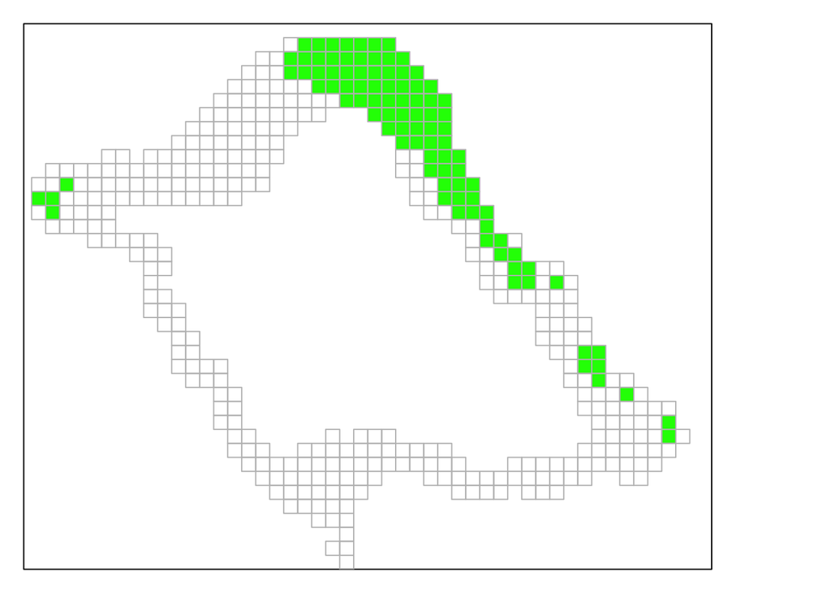

### Example Pareto Frontier

As an example, we can trace a Pareto Frontier under two objectives, conservation value (maximize) and opportunity cost (minimize) under fixed total area (A = 0.3) and compactness constraints. This is done by solving the ILP model under varying conservation constraints. The solutions are plotted below, color-coded by the compactness constraint.

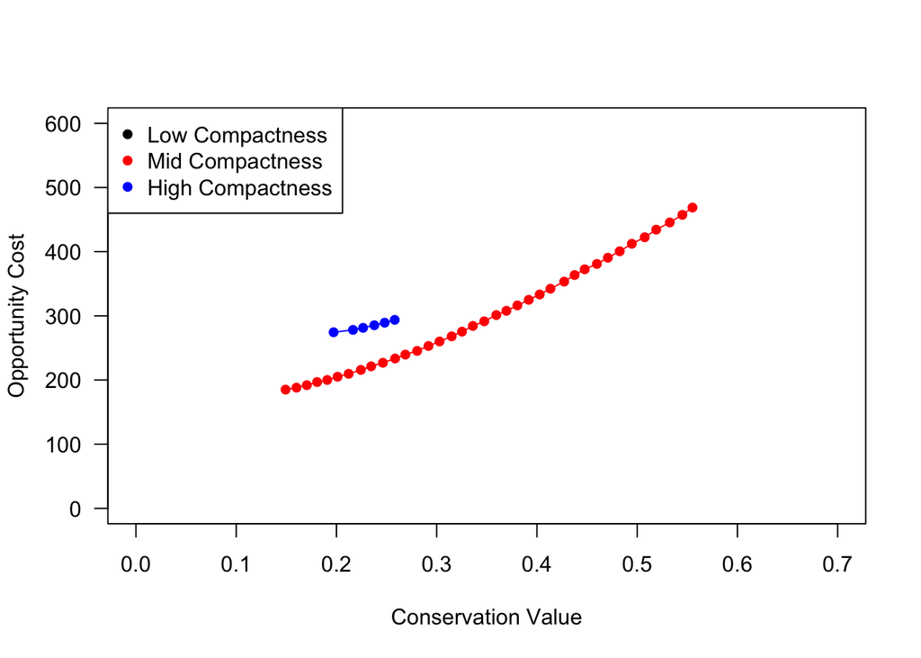